# analysis

```python
from statsmodels.stats.outliers_influence import variance_inflation_factor
import numpy as np
import pandas as pd
import seaborn as sns
import matplotlib.pyplot as plt
from sklearn.preprocessing import StandardScaler
from sklearn.decomposition import FastICA
from sklearn.decomposition import PCA
from sklearn.preprocessing import StandardScaler
from scipy import stats
from scipy.stats import shapiro, levene, ttest_ind, mannwhitneyu
from mpl_toolkits.mplot3d import Axes3D
```

```python
df = pd.read_csv('./csv/preprocessed_data.csv')
df.head()
```

|  | Group | Rt_scale_IKI-mean | Rt_scale_IKI-SD | Rt_scale_IRI-mean | Rt_scale_IRI-SD | Rt_long_scale_IKI-mean | Rt_long_scale_IKI-SD | Rt_long_scale_IRI-mean | Rt_long_scale_IRI-SD | Rt_arpeggio_IKI-mean | ... | Lt_long_scale_IKI-mean | Lt_long_scale_IKI-SD | Lt_long_scale_IRI-mean | Lt_long_scale_IRI-SD | Lt_arpeggio_IKI-mean | Lt_arpeggio_IKI-SD | Lt_arpeggio_IRI-mean | Lt_arpeggio_IRI-SD | handedness | affected side |
| --- | --- | --- | --- | --- | --- | --- | --- | --- | --- | --- | --- | --- | --- | --- | --- | --- | --- | --- | --- | --- | --- |
| 0 | 1 | 82.312112 | 13.229921 | 82.135133 | 28.898811 | 86.265478 | 13.311980 | 86.875652 | 39.062791 | 90.066294 | ... | 95.666406 | 13.465412 | 96.125029 | 39.938112 | 101.131731 | 16.358171 | 102.647460 | 40.739545 | R | NaN |
| 1 | 1 | 88.946394 | 12.973927 | 89.013980 | 31.402664 | 98.032472 | 12.947017 | 105.671697 | 54.441392 | 118.003340 | ... | 104.111900 | 14.654740 | 111.136122 | 58.183404 | 168.127512 | 16.548132 | 168.258340 | 27.776093 | R | NaN |
| 2 | 1 | 69.061144 | 13.557577 | 71.281947 | 28.322600 | 90.262109 | 11.066986 | 90.212710 | 25.212559 | 83.783431 | ... | 96.978944 | 11.653787 | 96.649603 | 29.018465 | 97.928150 | 21.112888 | 98.374447 | 47.075235 | R | NaN |
| 3 | 1 | 104.627531 | 14.773290 | 103.568700 | 30.408687 | 128.489531 | 16.464423 | 127.964277 | 35.699352 | 150.809331 | ... | 161.587047 | 17.913393 | 161.105616 | 40.423535 | 180.687931 | 16.687300 | 180.634780 | 35.095249 | R | NaN |
| 4 | 1 | 88.024163 | 15.166748 | 89.525860 | 22.041914 | 97.867809 | 12.792190 | 97.921832 | 30.024507 | 214.103394 | ... | 114.973956 | 12.947909 | 114.820481 | 37.861518 | 224.061081 | 12.329798 | 224.257727 | 18.891626 | R | NaN |

5 rows × 27 columns

```python
# 全ての演奏関連特徴量の多重共線性チェック
performance_features = [
    # 右手の特徴量（平均値のみ）
    'Rt_scale_IKI-mean', 'Rt_long_scale_IKI-mean', 'Rt_arpeggio_IKI-mean',
    'Rt_scale_IRI-mean', 'Rt_long_scale_IRI-mean', 'Rt_arpeggio_IRI-mean',
    # 左手の特徴量（平均値のみ）
    'Lt_scale_IKI-mean', 'Lt_long_scale_IKI-mean', 'Lt_arpeggio_IKI-mean',
    'Lt_scale_IRI-mean', 'Lt_long_scale_IRI-mean', 'Lt_arpeggio_IRI-mean'
]

X = df[performance_features]
```

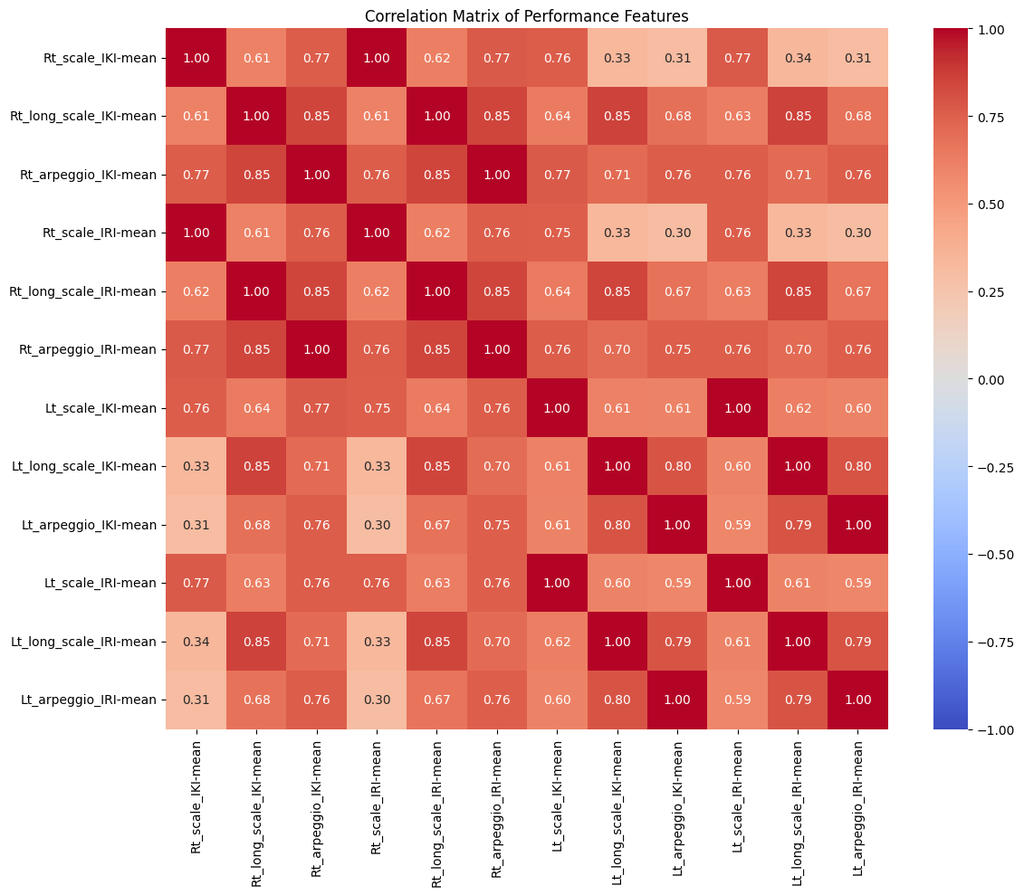

```python
# 相関行列の計算
correlation_matrix = X.corr()

# ヒートマップの作成
plt.figure(figsize=(12, 10))
sns.heatmap(correlation_matrix,
            annot=True,  # 相関係数を表示
            cmap='coolwarm',  # 色のパレット
            center=0,  # 0を中心とした色付け
            fmt='.2f',  # 小数点2桁まで表示
            vmin=-1, vmax=1)  # スケールの範囲
plt.title('Correlation Matrix of Performance Features')
plt.tight_layout()
plt.show()
```

```python
# VIF計算
X = df[performance_features]
vif_data = pd.DataFrame()
vif_data["Feature"] = X.columns
vif_data["VIF"] = [variance_inflation_factor(X.values, i) for i in range(X.shape[1])]

# VIFの結果を確認（値が大きい順にソート）
print(vif_data.sort_values('VIF', ascending=False))
```

```
                   Feature           VIF
11    Lt_arpeggio_IRI-mean  34638.007601
8     Lt_arpeggio_IKI-mean  33561.443742
5     Rt_arpeggio_IRI-mean  20331.275431
2     Rt_arpeggio_IKI-mean  19751.696341
4   Rt_long_scale_IRI-mean  10626.136611
1   Rt_long_scale_IKI-mean  10406.879366
7   Lt_long_scale_IKI-mean   8909.655697
10  Lt_long_scale_IRI-mean   8864.828207
0        Rt_scale_IKI-mean   8260.561555
3        Rt_scale_IRI-mean   8209.686043
9        Lt_scale_IRI-mean   6268.745018
6        Lt_scale_IKI-mean   6249.002407
```

# 演奏特徴量の分析方針

## 1. 多重共線性の確認と特徴量の整理

### 発見された相関関係

- IKI-meanとIRI-meanに強い相関（r ≈ 1.0）
  - 演奏の速さを反映
  - IKI-meanのみを使用することで冗長性を削減可能
- タスク間の相関
  - long_scaleとarpeggioの間に強い相関 (r ≈ 0.85)
  - scaleは他のタスクとやや弱い相関（r = 0.6-0.7）
- 左右の手の相関は中程度（r = 0.6-0.8）

### IKI-SDとIRI-SDの意味の違い

- **IKI-SD**: 打鍵タイミングのばらつき
  - リズムの安定性を反映
- **IRI-SD**: 離鍵タイミングのばらつき
  - アーティキュレーションのコントロールを反映
  - 演奏家は離鍵を意識的にコントロールしていない可能性

## 2. 分析用の特徴量セット

### 基本特徴量

```python
performance_features = [
# 右手の特徴量
'Rt_scale_IKI-mean', 'Rt_scale_IKI-SD', 'Rt_scale_IRI-SD',
'Rt_long_scale_IKI-mean', 'Rt_long_scale_IKI-SD', 'Rt_long_scale_IRI-SD',
'Rt_arpeggio_IKI-mean', 'Rt_arpeggio_IKI-SD', 'Rt_arpeggio_IRI-SD',
# 左手の特徴量
'Lt_scale_IKI-mean', 'Lt_scale_IKI-SD', 'Lt_scale_IRI-SD',
'Lt_long_scale_IKI-mean', 'Lt_long_scale_IKI-SD', 'Lt_long_scale_IRI-SD',
'Lt_arpeggio_IKI-mean', 'Lt_arpeggio_IKI-SD', 'Lt_arpeggio_IRI-SD'
]
```

### 派生特徴量の検討

- アーティキュレーションの一貫性指標（IRI-SD/IKI-SD）
- 左右の手の協調性指標
- タスク間の安定性の比較

## 3. 次のステップ

1. 健常者群とジストニア群の比較分析
2. 影響を受けている側（affected side）との関連分析
3. fMRIデータとの統合に向けた特徴量の選定

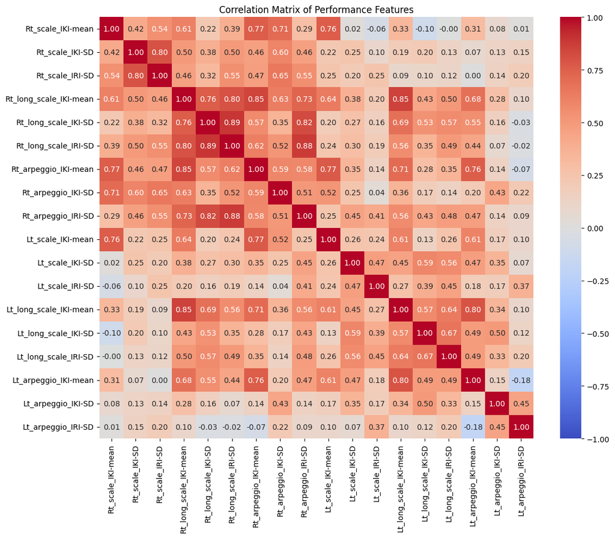

```python
# 新しい特徴量セットでの相関分析

# 相関行列の計算と可視化
correlation_matrix = df[performance_features].corr()

plt.figure(figsize=(12, 10))
sns.heatmap(correlation_matrix,
            annot=True,  # 相関係数を表示
            cmap='coolwarm',  # 色のパレット
            center=0,  # 0を中心とした色付け
            fmt='.2f',  # 小数点2桁まで表示
            vmin=-1, vmax=1)  # スケールの範囲
plt.title('Correlation Matrix of Performance Features')
plt.tight_layout()
plt.show()
```

```python
# VIF計算
X = df[performance_features]
vif_data = pd.DataFrame()
vif_data["Feature"] = X.columns
vif_data["VIF"] = [variance_inflation_factor(X.values, i) for i in range(X.shape[1])]

# VIFの結果を確認（値が大きい順にソート）
print(vif_data.sort_values('VIF', ascending=False))
```

```
                   Feature         VIF
9        Lt_scale_IKI-mean  175.523940
12  Lt_long_scale_IKI-mean  153.772838
3   Rt_long_scale_IKI-mean  141.094414
6     Rt_arpeggio_IKI-mean  115.289457
0        Rt_scale_IKI-mean   91.455020
15    Lt_arpeggio_IKI-mean   90.585333
5     Rt_long_scale_IRI-SD   81.236014
7       Rt_arpeggio_IKI-SD   71.747439
8       Rt_arpeggio_IRI-SD   67.369646
14    Lt_long_scale_IRI-SD   53.153002
16      Lt_arpeggio_IKI-SD   52.456584
11         Lt_scale_IRI-SD   49.169921
13    Lt_long_scale_IKI-SD   38.192386
2          Rt_scale_IRI-SD   36.485741
10         Lt_scale_IKI-SD   34.577666
4     Rt_long_scale_IKI-SD   34.195203
1          Rt_scale_IKI-SD   33.573900
17      Lt_arpeggio_IRI-SD   24.266709
```

# 演奏特徴量の分析（改訂版）

## 1. 特徴量の再定義と意味

- IKI-mean: 打鍵間隔の平均（演奏の速さ）
- IKI-SD: 打鍵タイミングのばらつき（リズムの安定性）
- IRI-SD: 離鍵タイミングのばらつき（アーティキュレーションの一貫性）

### リズムとアーティキュレーションの違い

1. **リズム (IKI関連)**
   - 音と音の「間隔」（タイミング）のパターン
   - 例：メトロノームに合わせて等間隔で弾く
2. **アーティキュレーション (IRI関連)**
   - 個々の音の「長さ」や「つなぎ方」
   - 例：スタッカート（短く切る）vs レガート（なめらかにつなぐ）

## 2. 多重共線性の分析結果

### VIF分析の結果

1. **mean値（VIF: 90-175）**

   ```
   Lt_scale_IKI-mean      175.52
   Lt_long_scale_IKI-mean 153.77
   Rt_long_scale_IKI-mean 141.09
   Rt_arpeggio_IKI-mean   115.29
   Rt_scale_IKI-mean       91.46
   Lt_arpeggio_IKI-mean    90.59
   ```

2. **SD値（VIF: 24-81）**

   ```
   Rt_long_scale_IRI-SD    81.24
   Rt_arpeggio_IKI-SD      71.75
   ...
   Lt_arpeggio_IRI-SD      24.27
   ```

### 解釈

1. **mean値の高いVIF**
   - 演奏の「速さ」を反映
   - 同じ人が速く弾くなら全てのタスクで速い傾向
   - → 変数間で情報が重複
2. **SD値の比較的低いVIF**
   - リズム（IKI-SD）とアーティキュレーション（IRI-SD）は異なる側面を測定
   - タスクごとの難しさも異なる
   - → より独立した情報を含む

## 3. 推奨される分析アプローチ

1. mean値は選択的に使用
   - タスクごとに代表的な特徴量を選択
2. SD値は積極的に活用
   - リズムとアーティキュレーションの両面を評価
3. 新しい指標の検討
   - アーティキュレーションの一貫性（IRI-SD/IKI-SD）
   - 左右の手の協調性
   - タスク間の安定性比較

```python
# 基本特徴量の再定義（IKI-meanのみ）
basic_features = [
    # 右手の特徴量
    'Rt_scale_IKI-mean', 'Rt_scale_IKI-SD', 'Rt_scale_IRI-SD',
    'Rt_long_scale_IKI-mean', 'Rt_long_scale_IKI-SD', 'Rt_long_scale_IRI-SD',
    'Rt_arpeggio_IKI-mean', 'Rt_arpeggio_IKI-SD', 'Rt_arpeggio_IRI-SD',
    # 左手の特徴量
    'Lt_scale_IKI-mean', 'Lt_scale_IKI-SD', 'Lt_scale_IRI-SD',
    'Lt_long_scale_IKI-mean', 'Lt_long_scale_IKI-SD', 'Lt_long_scale_IRI-SD',
    'Lt_arpeggio_IKI-mean', 'Lt_arpeggio_IKI-SD', 'Lt_arpeggio_IRI-SD'
]

# 新しい特徴量の作成
def create_derived_features(df):
    derived_features = pd.DataFrame()

    # アーティキュレーションの一貫性指標（IRI-SD/IKI-SD）
    tasks = ['scale', 'long_scale', 'arpeggio']
    hands = ['Rt', 'Lt']

    for hand in hands:
        for task in tasks:
            col_name = f'{hand}_{task}_articulation_consistency'
            iri_sd = df[f'{hand}_{task}_IRI-SD']
            iki_sd = df[f'{hand}_{task}_IKI-SD']
            derived_features[col_name] = iri_sd / iki_sd

    # 左右の手の協調性指標（mean値の差の絶対値）
    for task in tasks:
        col_name = f'{task}_hands_coordination_mean'
        rt_mean = df[f'Rt_{task}_IKI-mean']
        lt_mean = df[f'Lt_{task}_IKI-mean']
        derived_features[col_name] = abs(rt_mean - lt_mean)

        # SDの協調性も追加
        col_name = f'{task}_hands_coordination_SD'
        rt_sd = df[f'Rt_{task}_IKI-SD']
        lt_sd = df[f'Lt_{task}_IKI-SD']
        derived_features[col_name] = abs(rt_sd - lt_sd)

    return derived_features

# 新しい特徴量の作成
derived_features = create_derived_features(df)

# 基本特徴量と派生特徴量の結合
analysis_df = pd.concat([df[basic_features], derived_features], axis=1)

# 新しい特徴量セットの確認
print("新しい特徴量の一覧:")
print("\nアーティキュレーションの一貫性指標:")
print([col for col in derived_features.columns if 'articulation_consistency' in col])
print("\n左右の手の協調性指標:")
print([col for col in derived_features.columns if 'hands_coordination' in col])
```

```
新しい特徴量の一覧:

アーティキュレーションの一貫性指標:
['Rt_scale_articulation_consistency', 'Rt_long_scale_articulation_consistency', 'Rt_arpeggio_articulation_consistency', 'Lt_scale_articulation_consistency', 'Lt_long_scale_articulation_consistency', 'Lt_arpeggio_articulation_consistency']

左右の手の協調性指標:
['scale_hands_coordination_mean', 'scale_hands_coordination_SD', 'long_scale_hands_coordination_mean', 'long_scale_hands_coordination_SD', 'arpeggio_hands_coordination_mean', 'arpeggio_hands_coordination_SD']
```

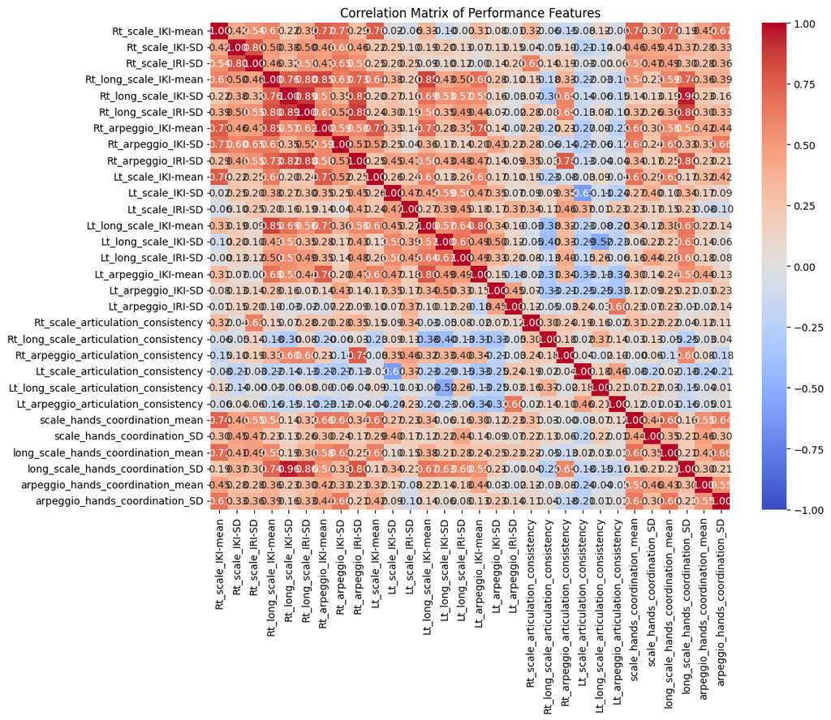

```
VIF values (sorted):
                                   Feature          VIF
2                          Rt_scale_IRI-SD  1397.595052
1                          Rt_scale_IKI-SD  1360.348415
14                    Lt_long_scale_IRI-SD  1332.699156
15                    Lt_arpeggio_IKI-mean  1231.202985
13                    Lt_long_scale_IKI-SD  1218.991996
18       Rt_scale_articulation_consistency  1121.980168
6                     Rt_arpeggio_IKI-mean  1062.365698
22  Lt_long_scale_articulation_consistency  1024.973744
8                       Rt_arpeggio_IRI-SD   965.948544
7                       Rt_arpeggio_IKI-SD   901.052789
20    Rt_arpeggio_articulation_consistency   824.460000
5                     Rt_long_scale_IRI-SD   811.711534
4                     Rt_long_scale_IKI-SD   655.794039
```

[output cut: 17 more lines]

```python
# 相関行列の計算と可視化
correlation_matrix = analysis_df.corr()

plt.figure(figsize=(12, 10))
sns.heatmap(correlation_matrix,
            annot=True,  # 相関係数を表示
            cmap='coolwarm',  # 色のパレット
            center=0,  # 0を中心とした色付け
            fmt='.2f',  # 小数点2桁まで表示
            vmin=-1, vmax=1)  # スケールの範囲
plt.title('Correlation Matrix of Performance Features')
plt.tight_layout()
plt.show()

# VIF計算
X = analysis_df
vif_data = pd.DataFrame()
vif_data["Feature"] = X.columns
vif_data["VIF"] = [variance_inflation_factor(X.values, i) for i in range(X.shape[1])]

# VIFの結果を確認（値が大きい順にソート）
print("\nVIF values (sorted):")
print(vif_data.sort_values('VIF', ascending=False))
```

# 演奏特徴量の分析（VIF分析結果）

## 1. VIFの分布パターン

### 非常に高いVIF (>1000)

```
Rt_scale_IRI-SD                      1397.60
Rt_scale_IKI-SD                      1360.35
Lt_long_scale_IRI-SD                 1332.70
Lt_arpeggio_IKI-mean                 1231.20
Lt_long_scale_IKI-SD                 1219.00
Rt_scale_articulation_consistency     1122.00
```

### 中程度のVIF (400-1000)

- 多くの基本特徴量（IKI-mean, IKI-SD, IRI-SD）
- いくつかのアーティキュレーション一貫性指標

### 比較的低いVIF (<50)

```
long_scale_hands_coordination_mean    35.27
scale_hands_coordination_mean         27.73
scale_hands_coordination_SD           11.72
arpeggio_hands_coordination_SD        11.33
```

## 2. 重要な発見

### 手の協調性指標が有望

- 左右の手の協調性を示す指標が最も低いVIF値を示している
- これらの指標は比較的独立した情報を持っている可能性が高い

### アーティキュレーション一貫性の問題

- 予想に反して、アーティキュレーション一貫性指標は高いVIF値を示している
- これは元のSD値との強い相関を示唆

## 3. 推奨される対応策

```
# より独立性の高い特徴量セットの例
selected_features = [
    # 基本的な速度指標（各タスクから1つ）
    'Rt_scale_IKI-mean',
    'Rt_long_scale_IKI-mean',
    'Rt_arpeggio_IKI-mean',

    # 手の協調性指標（VIFが低い）
    'scale_hands_coordination_mean',
    'scale_hands_coordination_SD',
    'long_scale_hands_coordination_mean',
    'arpeggio_hands_coordination_SD',

    # 代表的なSD値（選択的に）
    'Rt_scale_IKI-SD',
    'Lt_scale_IRI-SD'
]
```

## 4. 次のステップ

1. 手の協調性指標を中心とした分析の検討
2. アーティキュレーション一貫性指標の再設計の可能性
3. 基本特徴量の更なる選択的使用

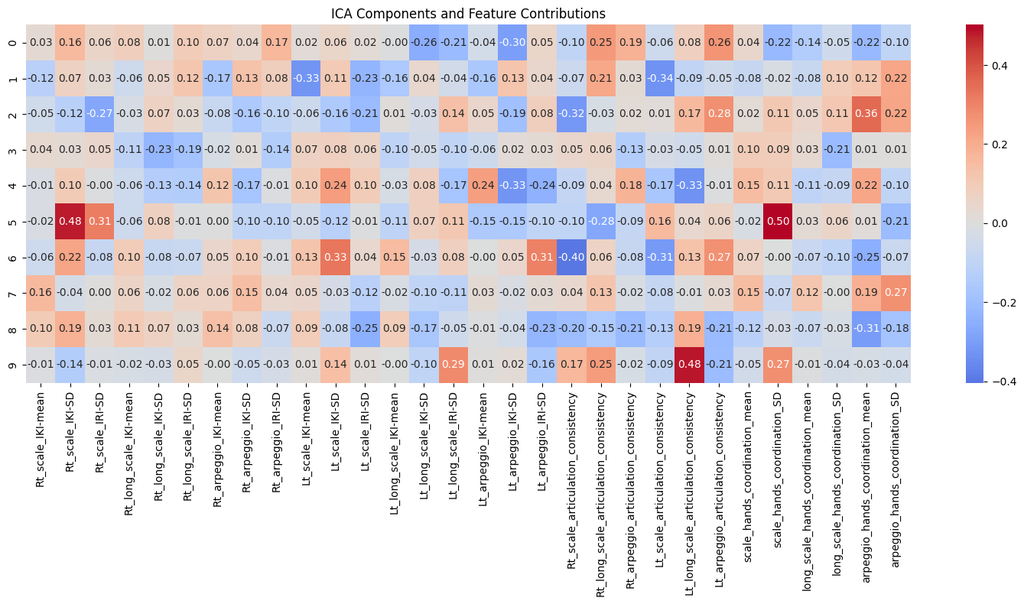

```
Component 1 most important features:
Lt_arpeggio_IKI-SD                        0.299774
Lt_arpeggio_articulation_consistency      0.262494
Lt_long_scale_IKI-SD                      0.256515
Rt_long_scale_articulation_consistency    0.249744
scale_hands_coordination_SD               0.218695
Name: 0, dtype: float64

Component 2 most important features:
Lt_scale_articulation_consistency         0.336184
Lt_scale_IKI-mean                         0.325651
Lt_scale_IRI-SD                           0.230946
arpeggio_hands_coordination_SD            0.218923
Rt_long_scale_articulation_consistency    0.212757
Name: 1, dtype: float64

Component 3 most important features:
arpeggio_hands_coordination_mean        0.357299
Rt_scale_articulation_consistency       0.317362
Lt_arpeggio_articulation_consistency    0.276792
Rt_scale_IRI-SD                         0.274066
arpeggio_hands_coordination_SD          0.221271
Name: 2, dtype: float64

Component 4 most important features:
Rt_long_scale_IKI-SD                    0.228966
long_scale_hands_coordination_SD        0.210713
Rt_long_scale_IRI-SD                    0.185515
Rt_arpeggio_IRI-SD                      0.136674
Rt_arpeggio_articulation_consistency    0.134921
Name: 3, dtype: float64

Component 5 most important features:
Lt_long_scale_articulation_consistency    0.334222
Lt_arpeggio_IKI-SD                        0.325499
Lt_arpeggio_IRI-SD                        0.243957
Lt_scale_IKI-SD                           0.241944
Lt_arpeggio_IKI-mean                      0.237744
Name: 4, dtype: float64

```

[output cut: 24 more lines]

```
Component 9 most important features:
arpeggio_hands_coordination_mean        0.305894
Lt_scale_IRI-SD                         0.247898
Lt_arpeggio_IRI-SD                      0.229656
Rt_arpeggio_articulation_consistency    0.211084
Lt_arpeggio_articulation_consistency    0.210801
Name: 8, dtype: float64

Component 10 most important features:
Lt_long_scale_articulation_consistency    0.481575
Lt_long_scale_IRI-SD                      0.286635
scale_hands_coordination_SD               0.272507
Rt_long_scale_articulation_consistency    0.246395
Lt_arpeggio_articulation_consistency      0.206669
Name: 9, dtype: float64
```

```python
# データの準備
# NaNを含む行を除外
analysis_df_clean = analysis_df.dropna()

# 標準化
scaler = StandardScaler()
X_scaled = scaler.fit_transform(analysis_df_clean)

# ICAの適用
# n_componentsは適切な数に調整する必要があります
ica = FastICA(n_components=10, random_state=42)
X_ica = ica.fit_transform(X_scaled)

# 独立成分の寄与を確認
components_df = pd.DataFrame(
    ica.components_,
    columns=analysis_df_clean.columns
)

# 各成分の特徴量への寄与を可視化
plt.figure(figsize=(15, 8))
sns.heatmap(components_df,
            cmap='coolwarm',
            center=0,
            annot=True,
            fmt='.2f')
plt.title('ICA Components and Feature Contributions')
plt.tight_layout()
plt.show()

# 各成分の解釈のために、最も寄与の大きい特徴量を表示
for i in range(components_df.shape[0]):
    print(f"\nComponent {i+1} most important features:")
    # 絶対値でソート
    sorted_features = components_df.iloc[i].abs().sort_values(ascending=False)
    print(sorted_features.head())
```

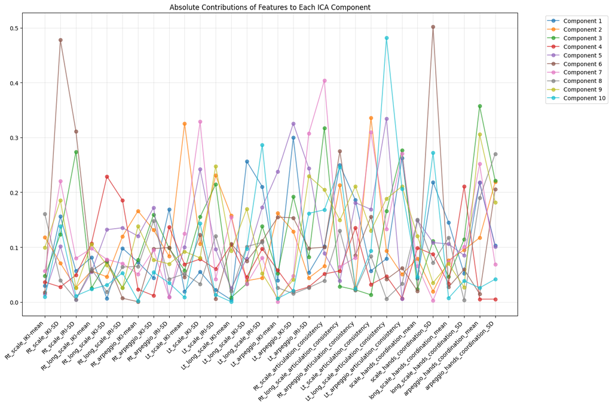

```
各成分の主な特徴：

Component 1の主な特徴：
Lt_arpeggio_IKI-SD                        0.299774
Lt_arpeggio_articulation_consistency      0.262494
Lt_long_scale_IKI-SD                      0.256515
Rt_long_scale_articulation_consistency    0.249744
scale_hands_coordination_SD               0.218695
Name: 0, dtype: float64

Component 2の主な特徴：
Lt_scale_articulation_consistency         0.336184
Lt_scale_IKI-mean                         0.325651
Lt_scale_IRI-SD                           0.230946
arpeggio_hands_coordination_SD            0.218923
Rt_long_scale_articulation_consistency    0.212757
Name: 1, dtype: float64

Component 3の主な特徴：
arpeggio_hands_coordination_mean        0.357299
Rt_scale_articulation_consistency       0.317362
Lt_arpeggio_articulation_consistency    0.276792
Rt_scale_IRI-SD                         0.274066
arpeggio_hands_coordination_SD          0.221271
Name: 2, dtype: float64

Component 4の主な特徴：
Rt_long_scale_IKI-SD                    0.228966
long_scale_hands_coordination_SD        0.210713
Rt_long_scale_IRI-SD                    0.185515
Rt_arpeggio_IRI-SD                      0.136674
Rt_arpeggio_articulation_consistency    0.134921
Name: 3, dtype: float64

Component 5の主な特徴：
Lt_long_scale_articulation_consistency    0.334222
Lt_arpeggio_IKI-SD                        0.325499
Lt_arpeggio_IRI-SD                        0.243957
Lt_scale_IKI-SD                           0.241944
Lt_arpeggio_IKI-mean                      0.237744
```

[output cut: 26 more lines]

```
Component 9の主な特徴：
arpeggio_hands_coordination_mean        0.305894
Lt_scale_IRI-SD                         0.247898
Lt_arpeggio_IRI-SD                      0.229656
Rt_arpeggio_articulation_consistency    0.211084
Lt_arpeggio_articulation_consistency    0.210801
Name: 8, dtype: float64

Component 10の主な特徴：
Lt_long_scale_articulation_consistency    0.481575
Lt_long_scale_IRI-SD                      0.286635
scale_hands_coordination_SD               0.272507
Rt_long_scale_articulation_consistency    0.246395
Lt_arpeggio_articulation_consistency      0.206669
Name: 9, dtype: float64
```

```python
# 各成分の寄与度を折れ線グラフで可視化
plt.figure(figsize=(15, 10))

# 各成分ごとに折れ線グラフを作成
for i in range(components_df.shape[0]):
    plt.plot(
        range(len(components_df.columns)),
        abs(components_df.iloc[i]),
        label=f'Component {i+1}',
        alpha=0.7,
        marker='o'
    )

plt.xticks(
    range(len(components_df.columns)),
    components_df.columns,
    rotation=45,
    ha='right'
)
plt.grid(True, alpha=0.3)
plt.legend(bbox_to_anchor=(1.05, 1), loc='upper left')
plt.title('Absolute Contributions of Features to Each ICA Component')
plt.tight_layout()
plt.show()

# 各成分の特徴的なパターンを解釈
print("\n各成分の主な特徴：")
for i in range(components_df.shape[0]):
    print(f"\nComponent {i+1}の主な特徴：")
    # 上位5つの特徴量を表示
    top_features = components_df.iloc[i].abs().sort_values(ascending=False).head()
    print(top_features)
```

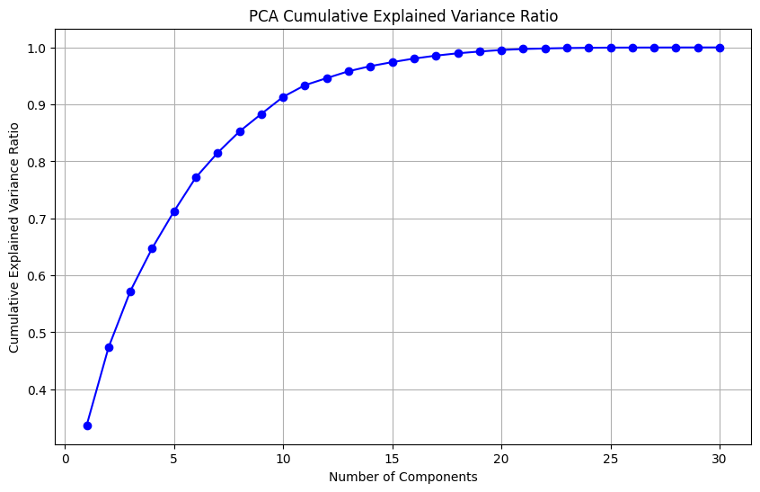

```
PCA explained variance ratio:
PC1: 0.337 (33.7%)
PC2: 0.136 (13.6%)
PC3: 0.099 (9.9%)
PC4: 0.075 (7.5%)
PC5: 0.065 (6.5%)
PC6: 0.060 (6.0%)
PC7: 0.043 (4.3%)
PC8: 0.037 (3.7%)
PC9: 0.031 (3.1%)
PC10: 0.030 (3.0%)
```

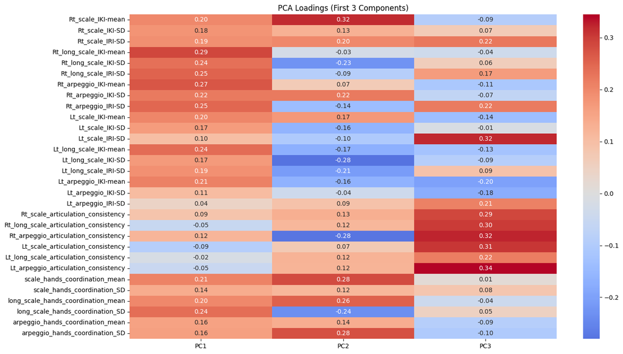

```python
# データの準備
analysis_df_clean = analysis_df.dropna()
X_scaled = StandardScaler().fit_transform(analysis_df_clean)

# PCAの実行
pca = PCA()
X_pca = pca.fit_transform(X_scaled)

# 寄与率の可視化
plt.figure(figsize=(10, 6))
plt.plot(range(1, len(pca.explained_variance_ratio_) + 1),
         np.cumsum(pca.explained_variance_ratio_), 'bo-')
plt.xlabel('Number of Components')
plt.ylabel('Cumulative Explained Variance Ratio')
plt.grid(True)
plt.title('PCA Cumulative Explained Variance Ratio')
plt.show()

# 各主成分の寄与率
print("\nPCA explained variance ratio:")
for i, ratio in enumerate(pca.explained_variance_ratio_[:10]):  # 上位10成分
    print(f"PC{i+1}: {ratio:.3f} ({ratio*100:.1f}%)")

# 主成分の負荷量（各特徴量の寄与）
loadings = pd.DataFrame(
    pca.components_.T,
    columns=[f'PC{i+1}' for i in range(pca.components_.shape[0])],
    index=analysis_df_clean.columns
)

# 上位3主成分の負荷量を可視化
plt.figure(figsize=(15, 8))
sns.heatmap(loadings.iloc[:, :3],
            cmap='coolwarm',
            center=0,
            annot=True,
            fmt='.2f')
plt.title('PCA Loadings (First 3 Components)')
plt.tight_layout()
plt.show()
```

# 主成分分析（PCA）結果の解釈

## 1. 寄与率の分布

- **PC1**: 33.7% - 最も重要な成分
- **PC2**: 13.6%
- **PC3**: 9.9%
- **合計**: 約57%の分散を説明
- **PC4-10**: それぞれ3-7%程度の寄与

## 2. 各主成分の特徴と解釈

### PC1（33.7%）: 「全体的な演奏の速さと安定性」

- **正の強い寄与**:
  - Rt_long_scale_IKI-mean (0.29)
  - Rt_arpeggio_IKI-mean (0.27)
  - Rt_arpeggio_IRI-SD (0.25)
  - Lt_long_scale_IKI-mean (0.24)
- **特徴**: 両手のIKI-mean (速さ) とSD (安定性) が同じ方向に寄与
- **解釈**: 演奏の基本的な速さと安定性を表す

### PC2（13.6%）: 「右手と左手の対比」

- **正の寄与**:
  - Rt_scale_IKI-mean (0.32)
  - scale_hands_coordination_mean (0.28)
- **負の寄与**:
  - Lt_long_scale_IKI-SD (-0.28)
  - Lt_long_scale_IRI-SD (-0.21)
- **特徴**: 右手と左手の特徴が逆方向に寄与
- **解釈**: 左右の手の協調性や非対称性を表す

### PC3（9.9%）: 「アーティキュレーションの一貫性」

- **正の強い寄与**:
  - Lt_arpeggio_articulation_consistency (0.34)
  - Lt_scale_IRI-SD (0.32)
  - Rt_arpeggio_articulation_consistency (0.32)
- **特徴**: アーティキュレーション関連の指標が強く寄与
- **解釈**: 音の切り方やつなぎ方の特徴を表す

## 3. 実践的な示唆

### 分析の焦点

1. **PC1**: 基本的な演奏能力の評価
2. **PC2**: 左右の手のバランス評価
3. **PC3**: アーティキュレーションの評価

### ジストニア研究への応用

- **PC2が特に重要**: 左右の非対称性を捉える
- **PC3も注目**: 細かい運動制御の特徴を反映

### 特徴量の選択への示唆

- 各PCの上位寄与特徴量を選択することで効率的な評価が可能
- 累積寄与率から最初の3-5成分で十分な情報が得られる

## 4. 結論

- このPCA結果は演奏の異なる側面 (基本的な演奏能力、左右の協調性、アーティキュレーション) を効率的に捉えており、ジストニアの評価に有用な情報を提供している。特に左右の非対称性 (PC2) は、ジストニアの特徴を反映している可能性が高い。

```python
# PCAスコアをデータフレームとして取得
pca_scores = pd.DataFrame(
    X_pca[:, :3],  # 最初の3つの主成分のみ
    columns=['PC1', 'PC2', 'PC3'],
    index=analysis_df_clean.index  # 元のインデックスを保持
)

# 元のデータフレームとPCAスコアを結合
df_with_pca = pd.concat([df[['Group']], pca_scores], axis=1)

# 確認
print("結合されたデータフレームの最初の数行:")
print(df_with_pca.head())

# 基本統計量の確認
print("\n各主成分のグループ別基本統計量:")
print(df_with_pca.groupby('Group').describe())
```

```
結合されたデータフレームの最初の数行:
   Group       PC1       PC2       PC3
0      1 -2.911406 -0.001977  1.432141
1      1 -0.336617 -0.279349  0.752567
2      1 -2.965089  0.183749 -0.086383
3      1 -0.354730 -0.567031 -0.789127
4      1 -1.953995 -0.438478 -1.921558

各主成分のグループ別基本統計量:
        PC1                                                             \
      count      mean       std       min       25%       50%      75%
Group
1      22.0 -0.961568  1.883950 -3.542163 -2.287425 -0.966813 -0.18091
2      22.0  0.961568  3.961785 -3.470310 -1.481734  0.051258  2.08163

                   PC2            ...                       PC3            \
             max count      mean  ...       75%       max count      mean
Group                             ...
1       5.294178  22.0 -0.129854  ...  0.044236  1.696028  22.0 -0.416778
2      12.407778  22.0  0.129854  ...  0.796250  8.668444  22.0  0.416778


            std       min       25%       50%       75%       max
Group
1      1.609820 -3.232419 -1.263924 -0.485323  0.471483  2.919899
2      1.807691 -3.220846 -0.596634  1.092048  1.808340  2.628973

[2 rows x 24 columns]
```

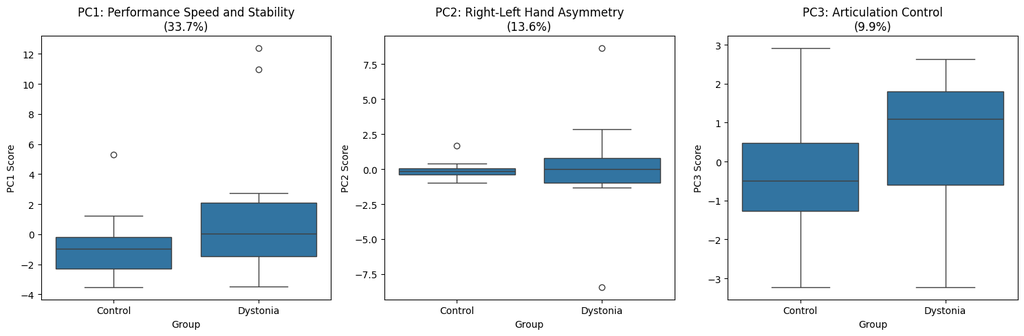

```python
# PCAスコアをデータフレームとして取得
pca_scores = pd.DataFrame(
    X_pca[:, :3],  # 最初の3つの主成分のみ
    columns=['PC1', 'PC2', 'PC3'],
    index=analysis_df_clean.index
)

# 元のデータフレームとPCAスコアを結合
df_with_pca = pd.concat([df[['Group']], pca_scores], axis=1).copy()

# Group名を変更
df_with_pca['Group'] = df_with_pca['Group'].map({1: 'Control', 2: 'Dystonia'})

# プロット
fig, axes = plt.subplots(1, 3, figsize=(15, 5))

# PC1の箱ひげ図
sns.boxplot(data=df_with_pca, x='Group', y='PC1', ax=axes[0])
axes[0].set_title('PC1: Performance Speed and Stability\n(33.7%)')
axes[0].set_ylabel('PC1 Score')

# PC2の箱ひげ図
sns.boxplot(data=df_with_pca, x='Group', y='PC2', ax=axes[1])
axes[1].set_title('PC2: Right-Left Hand Asymmetry\n(13.6%)')
axes[1].set_ylabel('PC2 Score')

# PC3の箱ひげ図
sns.boxplot(data=df_with_pca, x='Group', y='PC3', ax=axes[2])
axes[2].set_title('PC3: Articulation Control\n(9.9%)')
axes[2].set_ylabel('PC3 Score')

plt.tight_layout()
plt.show()
```

```python
def run_statistical_tests(df, variable):
    # グループごとのデータ取得
    control = df[df['Group'] == 'Control'][variable]
    dystonia = df[df['Group'] == 'Dystonia'][variable]

    # 1. Shapiro-Wilk test for normality
    _, p_normal_control = shapiro(control)
    _, p_normal_dystonia = shapiro(dystonia)
    normal_dist = (p_normal_control > 0.05) and (p_normal_dystonia > 0.05)

    # 2. Levene's test for equality of variances
    _, p_var = levene(control, dystonia)
    equal_var = p_var > 0.05

    # 3. Group comparison
    if normal_dist:
        # If normal distribution, use t-test
        stat, p_value = ttest_ind(control, dystonia, equal_var=equal_var)
        test_name = "t-test"
    else:
        # If not normal, use Mann-Whitney U test
        stat, p_value = mannwhitneyu(control, dystonia, alternative='two-sided')
        test_name = "Mann-Whitney U test"

    # Print results
    print(f"\nResults for {variable}:")
    print(f"Normality test p-values: Control: {p_normal_control:.3f}, Dystonia: {p_normal_dystonia:.3f}")
    print(f"Equal variance test p-value: {p_var:.3f}")
    print(f"Group comparison ({test_name}) p-value: {p_value:.3f}")

    # Calculate effect size (Cohen's d)
    d = (control.mean() - dystonia.mean()) / np.sqrt((control.var() + dystonia.var()) / 2)
    print(f"Effect size (Cohen's d): {d:.3f}")

    # Print descriptive statistics
    print("\nDescriptive statistics:")
    print(df.groupby('Group')[variable].describe())

# Run tests for each PC
for pc in ['PC1', 'PC2', 'PC3']:
    run_statistical_tests(df_with_pca, pc)
```

```
Results for PC1:
Normality test p-values: Control: 0.006, Dystonia: 0.000
Equal variance test p-value: 0.085
Group comparison (Mann-Whitney U test) p-value: 0.045
Effect size (Cohen's d): -0.620

Descriptive statistics:
          count      mean       std       min       25%       50%      75%  \
Group
Control    22.0 -0.961568  1.883950 -3.542163 -2.287425 -0.966813 -0.18091
Dystonia   22.0  0.961568  3.961785 -3.470310 -1.481734  0.051258  2.08163

                max
Group
Control    5.294178
Dystonia  12.407778

Results for PC2:
Normality test p-values: Control: 0.004, Dystonia: 0.000
Equal variance test p-value: 0.018
Group comparison (Mann-Whitney U test) p-value: 0.734
Effect size (Cohen's d): -0.126

Descriptive statistics:
          count      mean       std       min       25%       50%       75%  \
Group
Control    22.0 -0.129854  0.532700 -0.990095 -0.410241 -0.150485  0.044236
Dystonia   22.0  0.129854  2.872846 -8.451156 -0.982487 -0.002672  0.796250

               max
Group
Control   1.696028
Dystonia  8.668444

Results for PC3:
Normality test p-values: Control: 0.978, Dystonia: 0.014
Equal variance test p-value: 0.806
Group comparison (Mann-Whitney U test) p-value: 0.076
Effect size (Cohen's d): -0.487

Descriptive statistics:
          count      mean       std       min       25%       50%       75%  \
Group
Control    22.0 -0.416778  1.609820 -3.232419 -1.263924 -0.485323  0.471483
Dystonia   22.0  0.416778  1.807691 -3.220846 -0.596634  1.092048  1.808340

               max
Group
Control   2.919899
Dystonia  2.628973
```

# 主成分分析による群間比較結果

## 1. 統計的分析結果

### PC1: 演奏の速さと安定性（寄与率 33.7%）

- **統計的有意差**: あり (p = 0.045)
- **効果量**: 中程度から大きい (Cohen's d = -0.620)
- **記述統計**:
  - Dystonia群: 0.96 ± 3.96
  - Control群: -0.96 ± 1.88
- **特徴**: Dystonia群で顕著に大きい分散

### PC2: 左右の非対称性（寄与率 13.6%）

- **統計的有意差**: なし (p = 0.734)
- **効果量**: 小さい (Cohen's d = -0.126)
- **記述統計**:
  - Dystonia群: 0.13 ± 2.87
  - Control群: -0.13 ± 0.53
- **特徴**: Dystonia群で顕著に大きい分散

### PC3: アーティキュレーション（寄与率 9.9%）

- **統計的有意差**: なし (p = 0.076、傾向あり)
- **効果量**: 中程度 (Cohen's d = -0.487)
- **記述統計**:
  - Dystonia群: 0.42 ± 1.81
  - Control群: -0.42 ± 1.61
- **特徴**: 両群で比較的似た分散

## 2. 主要な知見

1. **明確な群間差**
   - PC1のみで統計的有意差を検出
   - 基本的な演奏能力の違いを反映
2. **分散の特徴**
   - PC1, PC2: Dystonia群で顕著に大きい分散
   - PC3: 両群で比較的均一な分散
3. **臨床的示唆**
   - PC1が診断マーカーとして有望
   - Dystonia群内での大きな個人差
   - PC3でも差がある傾向（p < 0.10）

## 3. 限界点と今後の課題

1. サンプルサイズの制約
2. Dystonia群内での大きな個人差の解釈
3. 非対称性（PC2）における予想外の結果の解明

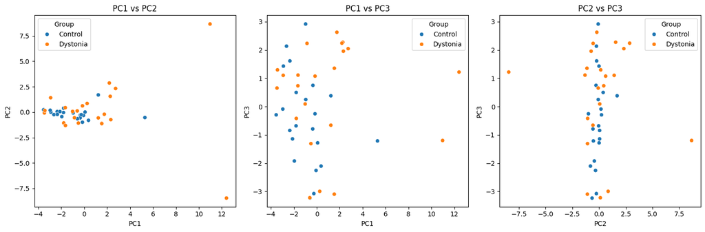

```python
# 主成分分析の結果を散布図で可視化

fig, axes = plt.subplots(1, 3, figsize=(15, 5))

# PC1 vs PC2
sns.scatterplot(data=df_with_pca, x='PC1', y='PC2', hue='Group', ax=axes[0])
axes[0].set_title('PC1 vs PC2')

# PC1 vs PC3
sns.scatterplot(data=df_with_pca, x='PC1', y='PC3', hue='Group', ax=axes[1])
axes[1].set_title('PC1 vs PC3')

# PC2 vs PC3
sns.scatterplot(data=df_with_pca, x='PC2', y='PC3', hue='Group', ax=axes[2])
axes[2].set_title('PC2 vs PC3')

plt.tight_layout()
plt.show()
```

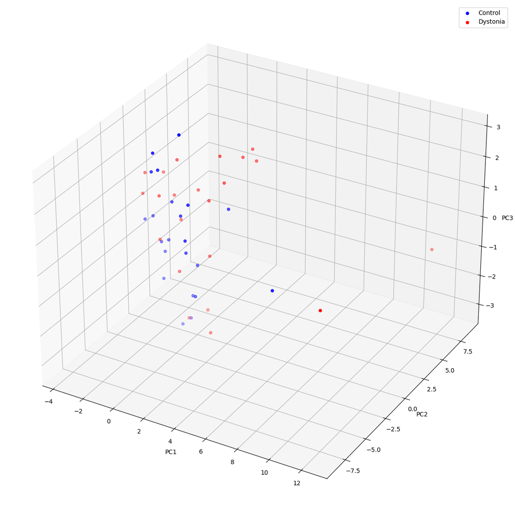

```python
# 3Dプロット


fig = plt.figure(figsize=(15, 15))
ax = fig.add_subplot(111, projection='3d')

# Control群
control = df_with_pca[df_with_pca['Group'] == 'Control']
ax.scatter(control['PC1'], control['PC2'], control['PC3'],
          c='blue', label='Control')

# Dystonia群
dystonia = df_with_pca[df_with_pca['Group'] == 'Dystonia']
ax.scatter(dystonia['PC1'], dystonia['PC2'], dystonia['PC3'],
          c='red', label='Dystonia')

ax.set_xlabel('PC1')
ax.set_ylabel('PC2')
ax.set_zlabel('PC3')
ax.legend()

plt.show()
```

```python
# インデックスをリセットせずにPCAスコアと元のデータを結合
df_with_pca = pd.concat([
    df[['Group', 'handedness', 'affected side']],  # 必要な列を追加
    pca_scores
], axis=1)

# 確認
print("最初の5行を表示:")
print(df_with_pca.head())

# 行数の確認
print("\n行数の確認:")
print(f"元のデータフレーム: {len(df)}")
print(f"PCAスコアデータフレーム: {len(df_with_pca)}")

# CSVとして保存（インデックスを含める）
df_with_pca.to_csv('./csv/pca_scores.csv', index=True)
```

```
最初の5行を表示:
   Group handedness affected side       PC1       PC2       PC3
0      1          R           NaN -2.911406 -0.001977  1.432141
1      1          R           NaN -0.336617 -0.279349  0.752567
2      1          R           NaN -2.965089  0.183749 -0.086383
3      1          R           NaN -0.354730 -0.567031 -0.789127
4      1          R           NaN -1.953995 -0.438478 -1.921558

行数の確認:
元のデータフレーム: 44
PCAスコアデータフレーム: 44
```